# Raptor Persecution Incidents

Buse Küçükçoban, Defne Bayrak

26/06/2021

# Raptor Persecution Incidents

TEAM: OXYGEN

26/06/2021

# Why did we do this project?

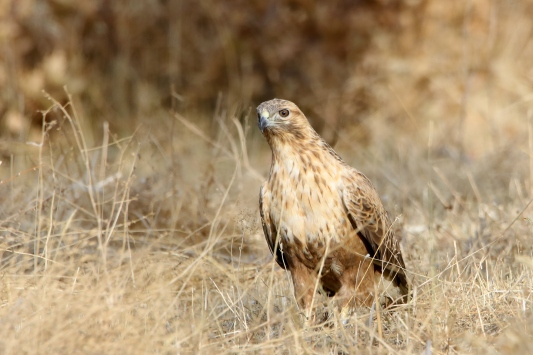

- As the damage to living beings increases day by day, we want to show the cruelty that predatory creatures also suffer.

# Project Goal & Societal Benefits

- Our main goal on this project is to create awareness about animal cruelty with hunting, and we want to show the effects of hunting, which is seen as a means of entertainment in society, on living things.

# Introduction of data & problem statement

We got our data from the RSPB open data source site.

[Source](https://opendata-rspb.opendata.arcgis.com/search?collection=Dataset&tags=Birdcrime)

Our data includes confirmed incidents of raptors that took place in the UK. The dataset consists of 1297 rows and 13 columns.

```
## 'data.frame':    1297 obs. of  13 variables:
##  $ ï..OBJECTID   : int  4399 4400 4401 4402 4403 4404 4405 4406 4407 4408 ...
##  $ RSPB_Reference: int  88508 99939 93075 95445 99099 98890 90310 93840 94264 99068 ...
##  $ County        : chr  "ABERDEENSHIRE" "NORTH YORKSHIRE" "DUMFRIES AND GALLOWAY" "ANGUS" ...
##  $ Incident_Type : chr  "Poisoning" "Shooting" "Nest Destruction" "Illegal Pole/Spring Trapping" ...
##  $ Month         : chr  "May" "July" "May" "February" ...
##  $ Year          : int  2007 2018 2010 2012 2016 2016 2008 2010 2011 2016 ...
##  $ Grid_Square   : chr  "NJ72" "SE05" "NS80" "NO48" ...
##  $ Details       : chr  "Species involved: Peregrine falcon x 2; poison bait (pigeon) x 1. Tested positive for: Carbofuran." "Species involved: Red kite x 1." "Species involved: Peregrine falcon nest." "Species involved: Buzzard x 1." ...
##  $ More_Info_Here: chr  "No Link" "https://northyorkshire.police.uk/news/appeal-for-information-after-red-kite-found-dead-in-the-yorkshire-dales/" "No Link" "No Link" ...
##  $ Country       : chr  "SCOTLAND" "ENGLAND" "SCOTLAND" "SCOTLAND" ...
##  $ GlobalID      : chr  "{434F45F6-1323-4254-8E28-41756CD62F67}" "{F78F8C70-122E-4E13-9904-0B5262AFF5C9}" "{33FDF6A7-99EF-4369-A396-65DAB8EB3EF3}" "{F4C9B2E8-07D1-45E7-B526-E86E5DC143C3}" ...
##  $ SHAPE_Length  : num  73995 67992 70241 73275 68237 ...
##  $ SHAPE_Area    : num  3.42e+08 2.89e+08 3.08e+08 3.36e+08 2.91e+08 ...
```

# Actions taken

- We import the libraries we will use

library(“tidyverse”) library(“ggplot2”) library(“dplyr”) library(“gapminder”) library(“tm”) library(“tmap”)

- We have shown the bird species in the detail column in a separate column, hiding the columns we do not need.

And our final data is:

```
##   ObjectId                County                Incident_Type    Month Year
## 1     4399         ABERDEENSHIRE                    Poisoning      May 2007
## 2     4400       NORTH YORKSHIRE                     Shooting     July 2018
## 3     4401 DUMFRIES AND GALLOWAY             Nest Destruction      May 2010
## 4     4402                 ANGUS Illegal Pole/Spring Trapping February 2012
## 5     4403                  DOWN                     Shooting    April 2016
##   Grid_Square          Country SHAPE_Length SHAPE_Area             Species
## 1        NJ72         SCOTLAND     73994.72  342200534     Peregrinefalcon
## 2        SE05          ENGLAND     67992.46  288935333             Redkite
## 3        NS80         SCOTLAND     70241.35  308364890 Peregrinefalconnest
## 4        NO48         SCOTLAND     73275.49  335580512             Buzzard
## 5         J02 NORTHERN IRELAND     68237.03  291017712         Sparrowhawk
```

# Distribution of incident types by country

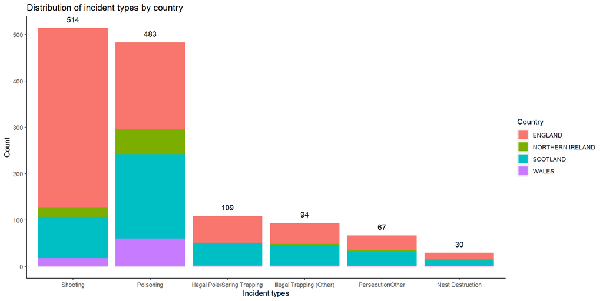

# Distribution and number of incident types by years

- From 2007 to 2019, we can say that the lowest incidents were in 2019, even if we did not observe a constant decrease. Every year we see poisoning or being shot head-on.

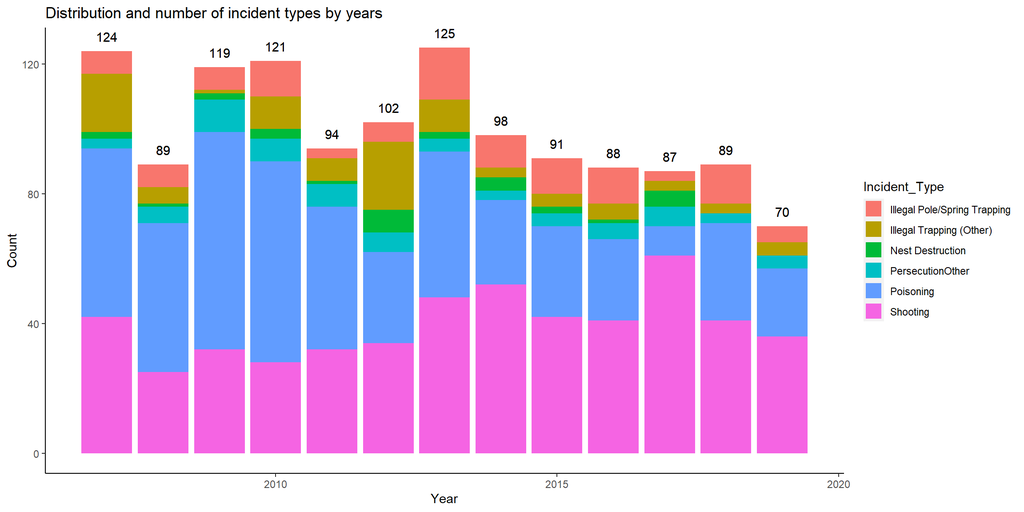

# Distribution of incidents by seasons

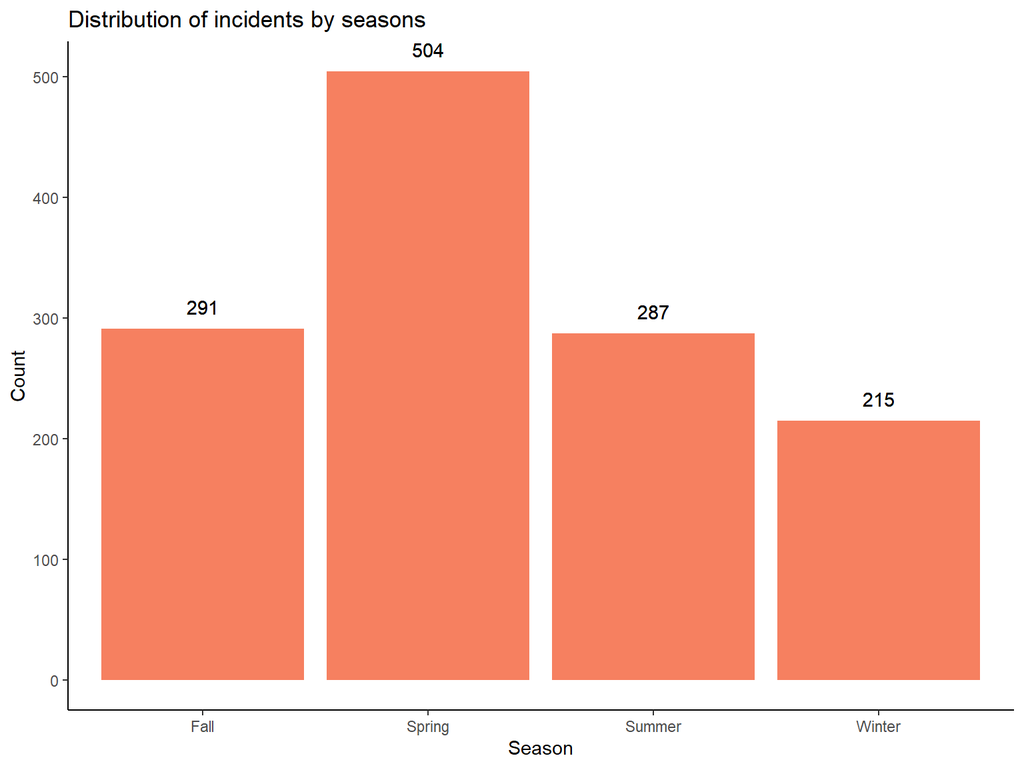

# 5 Counties with the highest incidents

- Angus, Highland, North Yorkshire, Perth and Kinross and Scottish Borders are one of the counties where the incidents took place the most.

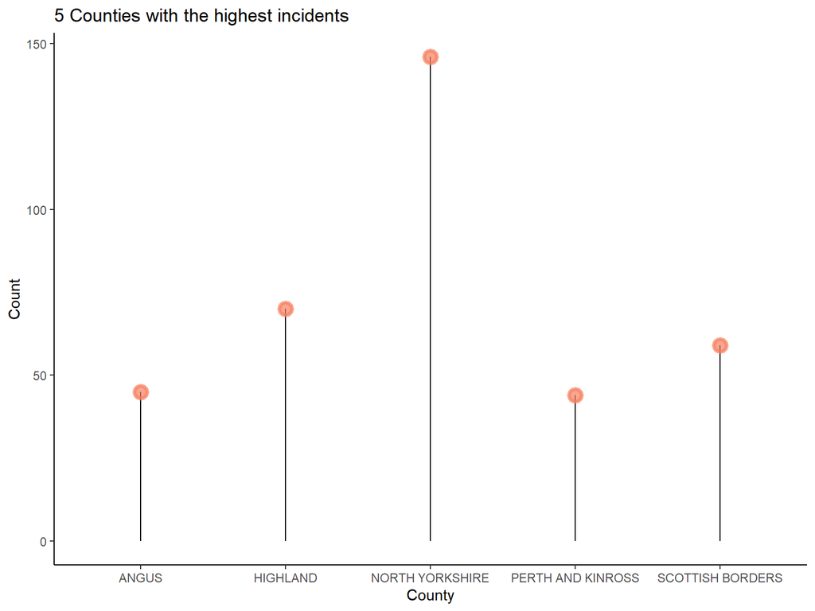

# Raptor most exposed to incidents

- Buzzards, other birds of prey and red kites are among the most exposed creatures.

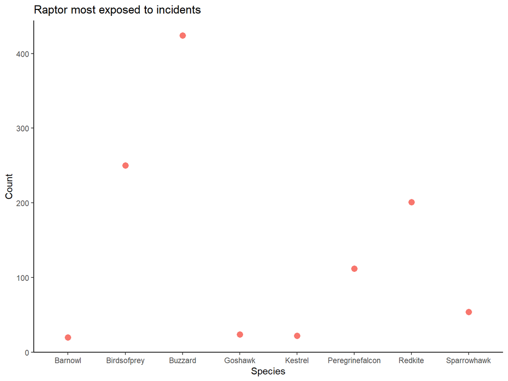

[output not shown]